# complete_the_square_A

## complete_the_square_A

#### Question

1. A large square comprises a yellow square, two congruent blue rectangles, and a red square.

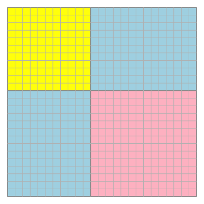

   The yellow square has an area of 121 little squares. The two blue rectangles have a combined area of 308 little squares.

   What is the area, in little squares, of the red square?

#### Solution

#### Question

2. A large square comprises a yellow square, two congruent blue rectangles, and a red square.

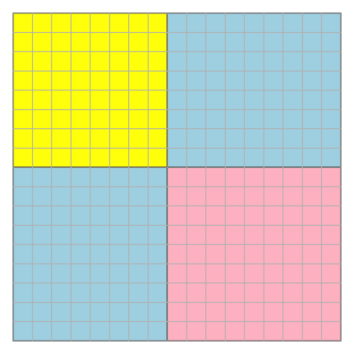

   The yellow square has an area of 64 little squares. The two blue rectangles have a combined area of 144 little squares.

   What is the area, in little squares, of the red square?

#### Solution

#### Question

3. A large square comprises a yellow square, two congruent blue rectangles, and a red square.

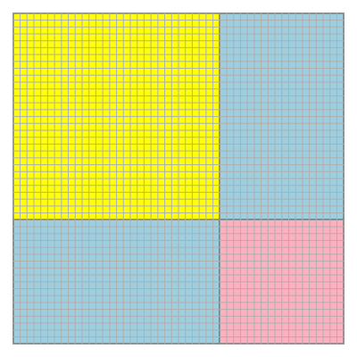

   The yellow square has an area of 900 little squares. The two blue rectangles have a combined area of 1080 little squares.

   What is the area, in little squares, of the red square?

#### Solution

#### Question

4. A large square comprises a yellow square, two congruent blue rectangles, and a red square.

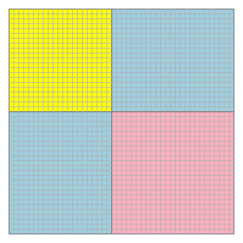

   The yellow square has an area of 441 little squares. The two blue rectangles have a combined area of 1050 little squares.

   What is the area, in little squares, of the red square?

#### Solution

#### Question

5. A large square comprises a yellow square, two congruent blue rectangles, and a red square.

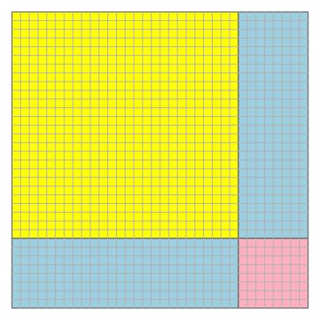

   The yellow square has an area of 676 little squares. The two blue rectangles have a combined area of 416 little squares.

   What is the area, in little squares, of the red square?

#### Solution

#### Question

6. A large square comprises a yellow square, two congruent blue rectangles, and a red square.

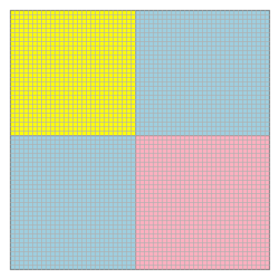

   The yellow square has an area of 784 little squares. The two blue rectangles have a combined area of 1680 little squares.

   What is the area, in little squares, of the red square?

#### Solution